# Tidy Tuesday Week 10

Paige Richards

3/3/2020

**For this week of TidyTuesday, I want to consider the plot from two different angles to learn two different skills:**

- ggridges
- emojifonts

Below, you will find the set up chunk for importing the data set. It is also printed to be able to view in the knitted document. I am going to look at the season goals for the year and I am importing the data using [this link](https://raw.githubusercontent.com/rfordatascience/tidytuesday/master/data/2020/2020-03-03/season_goals.csv).

```r
#tidytuesdayR::tt_load(2020, week=10) ->  nhl
#nhl$season_goals -> nhl_tibble
#nhl_tibble
  #This unfortunately only gave me the html of the tidytuesday data. Likely, I imported the dataset wrong
read_csv('https://raw.githubusercontent.com/rfordatascience/tidytuesday/master/data/2020/2020-03-03/season_goals.csv') -> season_goals_nhl
season_goals_nhl
```

```
## # A tibble: 4,810 x 23
##     rank position hand  player years total_goals status yr_start season   age
##    <dbl> <chr>    <chr> <chr>  <chr>       <dbl> <chr>     <dbl> <chr>  <dbl>
##  1     1 C        Left  Wayne… 1979…         894 Retir…     1979 1978-…    18
##  2     1 C        Left  Wayne… 1979…         894 Retir…     1979 1978-…    18
##  3     1 C        Left  Wayne… 1979…         894 Retir…     1979 1978-…    18
##  4     1 C        Left  Wayne… 1979…         894 Retir…     1979 1979-…    19
##  5     1 C        Left  Wayne… 1979…         894 Retir…     1979 1980-…    20
##  6     1 C        Left  Wayne… 1979…         894 Retir…     1979 1981-…    21
##  7     1 C        Left  Wayne… 1979…         894 Retir…     1979 1982-…    22
##  8     1 C        Left  Wayne… 1979…         894 Retir…     1979 1983-…    23
##  9     1 C        Left  Wayne… 1979…         894 Retir…     1979 1984-…    24
## 10     1 C        Left  Wayne… 1979…         894 Retir…     1979 1985-…    25
## # … with 4,800 more rows, and 13 more variables: team <chr>, league <chr>,
## #   season_games <dbl>, goals <dbl>, assists <dbl>, points <dbl>,
## #   plus_minus <dbl>, penalty_min <dbl>, goals_even <dbl>,
## #   goals_power_play <dbl>, goals_short_handed <dbl>, goals_game_winner <dbl>,
## #   headshot <chr>
```

```r
season_goals_nhl %>%
  dplyr::filter(status=='Active') -> wrangled_data_nhl
```

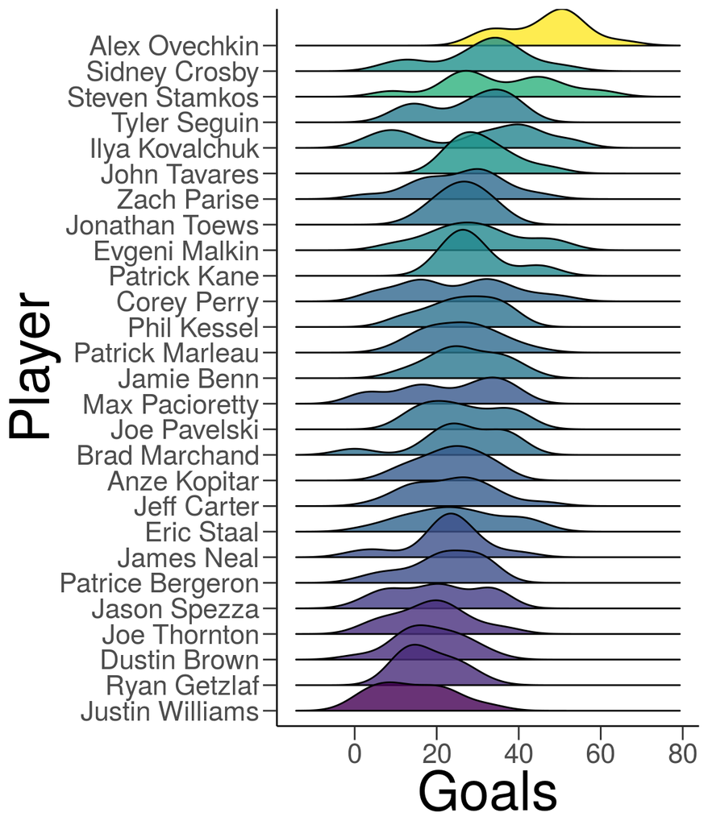

```r
wrangled_data_nhl %>%
  group_by(player)%>%
  mutate(mean_goals = mean(goals)) -> wrangled_data_nhl_2
ggplot(wrangled_data_nhl_2, aes(y=fct_reorder(player, goals), x=goals))+
         geom_density_ridges2(aes(fill=mean_goals), scale=1.8, alpha=0.8)+ #rel_min_height can change the trailing lines to be shorter. It looks stupid here. Scale can make it so they don't overlap (less than 1) but I like them overlapping.
  labs(y= 'Player',
       x= 'Goals')+
  scale_fill_viridis()+
  theme(legend.position='none', plot.title = element_text(size = rel(2.8)), axis.title=element_text(size=rel(3)), axis.text= element_text(size=rel(1.5)), axis.ticks.length.x= unit(0.3, "cm"), axis.ticks.length.y=unit(0.3, 'cm'))-> ggridges_nhl_plot
ggridges_nhl_plot
```

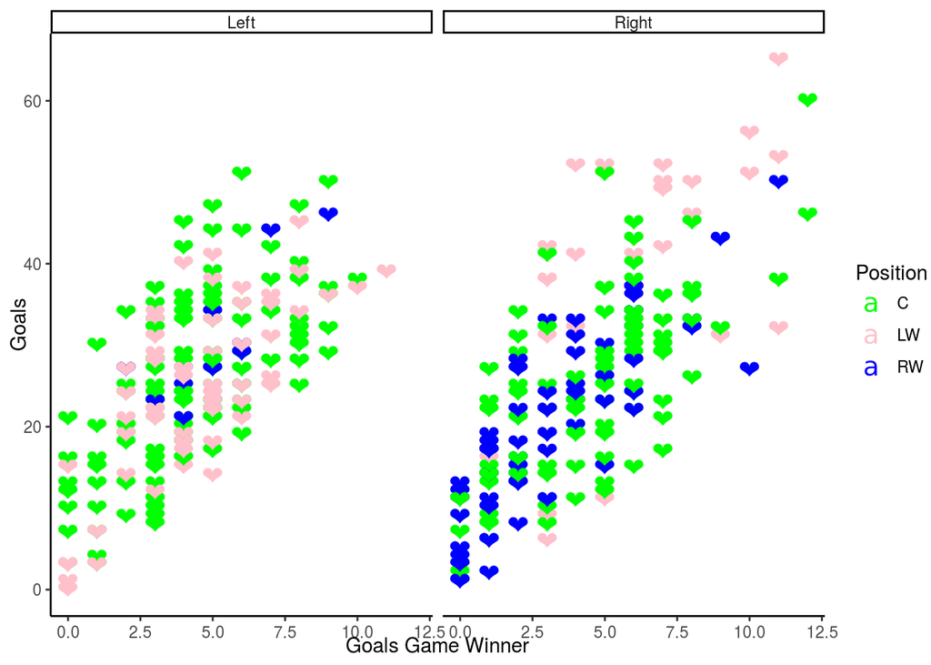

```r
ggsave('ggridges_nhl_plot.png', ggridges_nhl_plot,width = 5, height=7)
ggplot(wrangled_data_nhl, aes(y=goals, x=goals_game_winner,label=emoji('heart'), color=position), replace=TRUE)+ #discovered trophy was NOT a good emoji to use. Hearts are better because we heart hockey. Why does it fill in on the knitted document but not here? I have no idea
  geom_text(family='EmojiOne', size=5)+
  facet_grid(~hand)+
  labs(x='Goals Game Winner',
       y='Goals',
       color='Position')+
  scale_color_manual(values = c('green', 'pink', 'blue'))-> emoji_nhl_plot
emoji_nhl_plot
```

```r
ggsave ("emoji_nhl_plot.jpeg", emoji_nhl_plot)
```

It was really exciting to learn ggridges and emojifont. I feel like ggridges is such a useful graph for comparisons. In this one you can really see who gets more goals per actvive player which I like a lot. It was difficult to figure out how to wrangle this data because there were so many rows and it was hard to be able to see them all. I also liked trying to learn emojifont again. It was interesting trying to figure out what works and what doesn’t work. I don’t think I am 100% clear on this function but I think that what was produced was nice. I’m not sure how informative the graph was but I am hoping to gain some more experience with it and learn more about it. Overall, I feel like I have gained new skills with ggridges and emojifont. Additionally, I am learning how to write in HTML format for Rmarkdown files which is exciting as well!